# Exercise - Proteolytic cleavage; Beta-Lactoglobulin

Marc A.T. Teunis

2025-12-14

# Introduction

We use the protein Beta-lactoglobulin as an example to show an *in-silico* chemical analysis workflow in R/Bioconductor.

Here we will perform an enzymatic digestion on the native beta-lactoglobulin (`BLG`) protein of different species. We will use the Cow, Goat and the Sheep sequence to explore the theory behind mass-spectrometry. The amino acid sequence for the Beta-lac (`BLG`) gene for different organisms (Cow, Sheep & Goat) will be used.

We also practice a little with alignment in this exercise.

The name (`external_gene_name`) of the beta-lac encoding gene is `BLG`. Synonyms are: `PAEP`, `LGB` or `Beta-LG`

# Packages

Load the following packages in your session:

```r
library(biomaRt)
library(seqinr)
library(rentrez)
library(GEOquery)
library(Biostrings)
library(DECIPHER)
library(cleaver)
library(OrgMassSpecR)
library(protr)
library(tidyverse)
library(here)
```

# Data

Obtain the amino-acid sequences for the Beta-Lactoglobulin protein (`BLG`) from Goat (*C. hircus*), Sheep (*O. aries*) and Domestic Cow (*B. taurus*). See code chunks below.

## Retrieve amino acid sequence of `BLG` protein for Goat

Because the Goat sequence is not available via a Biomart search we download this sequence directly from Uniprot.

The following chunk downloads the amino acid sequence for the `BLG` protein from here:  
https://www.uniprot.org/uniprot/P02756.fasta And put the downloaded `.fasta` file in the `./data` folder.

```r
## download Goat aa sequence
## dir.create(here("data"))
url <- c("https://www.uniprot.org/uniprot/P02756.fasta")
download.file(url = url, destfile = here("data", "chircus_blg_aminoacids.fasta"))
```

## Convert to Amino Acids

```r
chircus_blg_aa <- Biostrings::readAAStringSet(filepath = here("data", "chircus_blg_aminoacids.fasta"))
names(chircus_blg_aa) <- c("chircus")
chircus_blg_aa
```

```
## AAStringSet object of length 1:
##     width seq                                               names
## [1]   180 MKCLLLALGLALACGIQAIIVTQ...LKALPMHIRLAFNPTQLEGQCHV chircus
```

Alternatively, you can also use the `{protr}` package to download sequences directly from UniProt:

```r
protr::getUniProt("P02756") %>%
  unlist %>%
  AAStringSet()
```

```
## AAStringSet object of length 1:
##     width seq
## [1]   180 MKCLLLALGLALACGIQAIIVTQTMKGLDIQKVA...KEALEKFDKALKALPMHIRLAFNPTQLEGQCHV
```

## Retrieve aa sequence of `BLG` protein for the Cow (`_B. taurus_`).

The BLG protein has multiple synonyms. The code below uses an `lapply` loop to test for each known synonym: `BLG`, `PAEP` `Beta-LG` and `LGB`

```r
## specify the 'market place' to use
mart <- useMart(biomart = "ensembl")
## specify from which 'dataset', in this case from Domestic Cow
btaurus_mart <- useDataset(
  dataset = "btaurus_gene_ensembl",
  mart = mart)

## there are several names for the same protein
beta_lac_gene_name <- c("BLG", "PAEP", "LGB", "Beta-LG")

attributes <- listAttributes(mart = btaurus_mart)

loop_gene_names <- function(x, mart){
  results <- getBM(
    attributes = c("ensembl_gene_id",        ## attributes are output
                   "external_gene_name",
                    "coding"),
    filters = "external_gene_name",          ## filters in input type
    values = x,
    mart = mart) %>%
    as_tibble()
    # print()
  return(results)
}

## "PAEP" yields a result, using that
query <- lapply(as.list(beta_lac_gene_name),
                loop_gene_names,
                mart = btaurus_mart)
query
```

```
## [[1]]
## # A tibble: 0 × 3
## # ℹ 3 variables: external_gene_name <lgl>, coding <lgl>, ensembl_gene_id <lgl>
##
## [[2]]
## # A tibble: 4 × 3
##   external_gene_name coding                                      ensembl_gene_id
##   <chr>              <chr>                                       <chr>
## 1 PAEP               ATGAAGTGCCTCCTGCTTGCCCTGGCCCTCACTTGTGGCGCC… ENSBTAG0000001…
## 2 PAEP               ATGGTGCCCAAGGCAGAAGCCACCCTCCAGGACACACCTGCC… ENSBTAG0000001…
## 3 PAEP               ATGAAGTGCCTCCTGCTTGCCCTGGCCCTCACTTGTGGCGCC… ENSBTAG0000001…
## 4 PAEP               ATGAAGTGCCTCCTGCTTGCCCTGGCCCTCACTTGTGGCGCC… ENSBTAG0000001…
##
## [[3]]
## # A tibble: 0 × 3
## # ℹ 3 variables: external_gene_name <lgl>, coding <lgl>, ensembl_gene_id <lgl>
##
## [[4]]
## # A tibble: 0 × 3
## # ℹ 3 variables: external_gene_name <lgl>, coding <lgl>, ensembl_gene_id <lgl>
```

```r
names(query) <- beta_lac_gene_name

## isolating the result in a dataframe
query_btaurus <- query[["PAEP"]]

btaurus_blg_aa <- DNAStringSet(query_btaurus$coding) %>% Biostrings::translate()
names(btaurus_blg_aa) <- c("btaurus_1", "btaurus_2", "btaurus_3")
btaurus_blg_aa
```

```
## AAStringSet object of length 4:
##     width seq                                               names
## [1]   237 MKCLLLALALTCGAQALIVTQTM...LGPPAWGRSSFSNKGINLCSPF* btaurus_1
## [2]   315 MVPKAEATLQDTPAPSAGSDLSL...KALPMHIRLSFNPTQLEEQCHI* btaurus_2
## [3]   246 MKCLLLALALTCGAQALIVTQTM...RSEPEGQVVQSRRPNFKTSKAL* btaurus_3
## [4]   253 MKCLLLALALTCGAQALIVTQTM...VSSPILTLPRHGSPSPTEQCHI* <NA>
```

## Retrieve aa sequence for Sheep

Now do the same for the Sheep `BLG` protein sequence. Use the code example above.

```r
mart <- useMart(biomart = "ensembl")
oaries_mart <- useDataset(dataset = "oaries_gene_ensembl",
                        mart=mart)

#datasets <- listDatasets(mart) %>% as_tibble()
attributes <- listAttributes(mart = oaries_mart)
#filters <- listFilters(chircus_mart)

## using loop again
query_sheep <- lapply(as.list(beta_lac_gene_name), loop_gene_names, mart = oaries_mart)
query_sheep
```

```
## [[1]]
## # A tibble: 0 × 3
## # ℹ 3 variables: external_gene_name <lgl>, coding <lgl>, ensembl_gene_id <lgl>
##
## [[2]]
## # A tibble: 4 × 3
##   external_gene_name coding                                      ensembl_gene_id
##   <chr>              <chr>                                       <chr>
## 1 PAEP               ATGAAGTACCTCCTGCTCGCCCTGGGCCTGGCCCTCGCCTGC… ENSOARG0002006…
## 2 PAEP               ATGAAGTGCCTCCTGCTTGCCCTGGGCCTGGCCCTCGCCTGT… ENSOARG0002004…
## 3 PAEP               ATGAAGTACCTCCTGCTCGCCCTGGGCCTGGCCCTCGCCTGC… ENSOARG0002006…
## 4 PAEP               GCCACCTGGTCCCTGCAGCTCAAGGTCCCTCCCCAGGTGGCG… ENSOARG0002006…
##
## [[3]]
## # A tibble: 0 × 3
## # ℹ 3 variables: external_gene_name <lgl>, coding <lgl>, ensembl_gene_id <lgl>
##
## [[4]]
## # A tibble: 0 × 3
## # ℹ 3 variables: external_gene_name <lgl>, coding <lgl>, ensembl_gene_id <lgl>
```

```r
names(query_sheep) <- beta_lac_gene_name
query_sheep <- query_sheep[["PAEP"]]
query_sheep
```

```
## # A tibble: 4 × 3
##   external_gene_name coding                                      ensembl_gene_id
##   <chr>              <chr>                                       <chr>
## 1 PAEP               ATGAAGTACCTCCTGCTCGCCCTGGGCCTGGCCCTCGCCTGC… ENSOARG0002006…
## 2 PAEP               ATGAAGTGCCTCCTGCTTGCCCTGGGCCTGGCCCTCGCCTGT… ENSOARG0002004…
## 3 PAEP               ATGAAGTACCTCCTGCTCGCCCTGGGCCTGGCCCTCGCCTGC… ENSOARG0002006…
## 4 PAEP               GCCACCTGGTCCCTGCAGCTCAAGGTCCCTCCCCAGGTGGCG… ENSOARG0002006…
```

```r
oaries_blg_aa <- DNAStringSet(query_sheep$coding) %>% Biostrings::translate()
names(oaries_blg_aa) <- "oaries"
oaries_blg_aa
```

```
## AAStringSet object of length 4:
##     width seq                                               names
## [1]   223 MKYLLLALGLALACCIQDAHIPQ...ASSPILTPPTTLPPPQGSATSR* oaries
## [2]   181 MKCLLLALGLALACGVQAIIVTQ...KALPMHIRLAFNPTQLEGQCHV* <NA>
## [3]   230 MKYLLLALGLALACCIQDAHIPQ...ASSPILTPPTTLPPPQGSATSR* <NA>
## [4]   210 ATWSLQLKVPPQVAGTWHPVAMV...ASSPILTPPTTLPPPQGSATSR* <NA>
```

Combine the three separate amino acid sequences encoding the `BLG` protein from Cow, Goat and Sheep to one `AAStringSet`. Provide appropriate names for each sequence by setting names using `names(...) <- c(...)`.

How long is each protein(fragment)?

```r
all_aa_trim <- c(btaurus_blg_aa,
                 oaries_blg_aa,
                 chircus_blg_aa)
all_aa_trim
```

```
## AAStringSet object of length 9:
##     width seq                                               names
## [1]   237 MKCLLLALALTCGAQALIVTQTM...LGPPAWGRSSFSNKGINLCSPF* btaurus_1
## [2]   315 MVPKAEATLQDTPAPSAGSDLSL...KALPMHIRLSFNPTQLEEQCHI* btaurus_2
## [3]   246 MKCLLLALALTCGAQALIVTQTM...RSEPEGQVVQSRRPNFKTSKAL* btaurus_3
## [4]   253 MKCLLLALALTCGAQALIVTQTM...VSSPILTLPRHGSPSPTEQCHI* <NA>
## [5]   223 MKYLLLALGLALACCIQDAHIPQ...ASSPILTPPTTLPPPQGSATSR* oaries
## [6]   181 MKCLLLALGLALACGVQAIIVTQ...KALPMHIRLAFNPTQLEGQCHV* <NA>
## [7]   230 MKYLLLALGLALACCIQDAHIPQ...ASSPILTPPTTLPPPQGSATSR* <NA>
## [8]   210 ATWSLQLKVPPQVAGTWHPVAMV...ASSPILTPPTTLPPPQGSATSR* <NA>
## [9]   180 MKCLLLALGLALACGIQAIIVTQ...LKALPMHIRLAFNPTQLEGQCHV chircus
```

## Exercise signal peptide trim and compare to Robert Jan

```r
all_aa_trim_trim <- AAStringSet(all_aa_trim, start = 17)
all_aa_trim_trim
```

```
## AAStringSet object of length 9:
##     width seq                                               names
## [1]   221 LIVTQTMKGLDIQKVAGTWYSLA...LGPPAWGRSSFSNKGINLCSPF* btaurus_1
## [2]   299 AGSDLSLSKRLTPEVFLALAASL...KALPMHIRLSFNPTQLEEQCHI* btaurus_2
## [3]   230 LIVTQTMKGLDIQKVAGTWYSLA...RSEPEGQVVQSRRPNFKTSKAL* btaurus_3
## [4]   237 LIVTQTMKGLDIQKVAGTWYSLA...VSSPILTLPRHGSPSPTEQCHI* <NA>
## [5]   207 QDAHIPQTVEDLDIRKVAGTWHP...ASSPILTPPTTLPPPQGSATSR* oaries
## [6]   165 QAIIVTQTMKGLDIQKVAGTWYS...KALPMHIRLAFNPTQLEGQCHV* <NA>
## [7]   214 QDAHIPQTVEDLDIRKVAGTWHP...ASSPILTPPTTLPPPQGSATSR* <NA>
## [8]   194 WHPVAMVASNIAAPLRVYVEELK...ASSPILTPPTTLPPPQGSATSR* <NA>
## [9]   164 QAIIVTQTMKGLDIQKVAGTWYS...LKALPMHIRLAFNPTQLEGQCHV chircus
```

```r
rjve_seq <- "LIVTQTMKGLDIQKVAGTWYSLAMAASDISLLDAQSAPLRVYVEELKPTPEGDLEILLQKWENDECAQKKIIAEKTKIPAVFKIDALNENKVLVLDTDYKKYLLVCMENSAEPEQSLVCQCLVRTPEVDDEALEKFDKALKALPMHIRLSFNPTQLEEQCHI"

rjve_seq <- AAStringSet(rjve_seq)
names(rjve_seq) <- "RJVE_seq"

new_sequences <- c(rjve_seq, all_aa_trim_trim)

alignment_blg <- AlignSeqs(new_sequences[1:4])
```

```
## Determining distance matrix based on shared 5-mers:
## ================================================================================
##
## Time difference of 0 secs
##
## Clustering into groups by similarity:
## ================================================================================
##
## Time difference of 0 secs
##
## Aligning Sequences:
## ================================================================================
##
## Time difference of 0.01 secs
##
## Iteration 1 of 2:
##
## Determining distance matrix based on alignment:
## ================================================================================
##
## Time difference of 0 secs
##
## Reclustering into groups by similarity:
## ================================================================================
##
## Time difference of 0 secs
##
## Realigning Sequences:
## ================================================================================
##
## Time difference of 0.01 secs
##
## Iteration 2 of 2:
##
## Determining distance matrix based on alignment:
## ================================================================================
##
## Time difference of 0 secs
##
## Reclustering into groups by similarity:
## ================================================================================
##
## Time difference of 0 secs
##
## Realigning Sequences:
## ================================================================================
##
## Time difference of 0 secs
```

```r
BrowseSeqs(alignment_blg)

alignment_blg
```

```
## AAStringSet object of length 4:
##     width seq                                               names
## [1]   387 -----------------------...----------------------- RJVE_seq
## [2]   387 -----------------------...LGPPAWGRSSFSNKGINLCSPF* btaurus_1
## [3]   387 AGSDLSLSKRLTPEVFLALAASL...----------------------* btaurus_2
## [4]   387 -----------------------...--------------NFKTSKAL* btaurus_3
```

# Multiple sequence alignment

**2A** Align the amino acid sequences for the `BLG` protein from Cow, Sheep and Goat. What can you conclude from this alignment?

```r
alignment_blg <- AlignSeqs(all_aa_trim_trim)
```

```
## Determining distance matrix based on shared 5-mers:
## ================================================================================
##
## Time difference of 0 secs
##
## Clustering into groups by similarity:
## ================================================================================
##
## Time difference of 0 secs
##
## Aligning Sequences:
## ================================================================================
##
## Time difference of 0.02 secs
##
## Iteration 1 of 2:
##
## Determining distance matrix based on alignment:
## ================================================================================
##
## Time difference of 0 secs
##
## Reclustering into groups by similarity:
## ================================================================================
##
## Time difference of 0 secs
##
## Realigning Sequences:
## ================================================================================
##
## Time difference of 0.23 secs
##
## Iteration 2 of 2:
##
## Determining distance matrix based on alignment:
## ================================================================================
##
## Time difference of 0 secs
##
## Reclustering into groups by similarity:
## ================================================================================
##
## Time difference of 0 secs
##
## Realigning Sequences:
## ================================================================================
##
## Time difference of 0 secs
```

```r
BrowseSeqs(alignment_blg)
```

Align the sequences for `BLG` protein from Cow and Sheep, what is you conclusion about the homology

```r
alignment_blg <- AlignSeqs(all_aa_trim_trim[c(1:4)])
```

```
## Determining distance matrix based on shared 5-mers:
## ================================================================================
##
## Time difference of 0 secs
##
## Clustering into groups by similarity:
## ================================================================================
##
## Time difference of 0 secs
##
## Aligning Sequences:
## ================================================================================
##
## Time difference of 0.01 secs
##
## Iteration 1 of 2:
##
## Determining distance matrix based on alignment:
## ================================================================================
##
## Time difference of 0 secs
##
## Reclustering into groups by similarity:
## ================================================================================
##
## Time difference of 0 secs
##
## Realigning Sequences:
## ================================================================================
##
## Time difference of 0.01 secs
##
## Iteration 2 of 2:
##
## Determining distance matrix based on alignment:
## ================================================================================
##
## Time difference of 0 secs
##
## Reclustering into groups by similarity:
## ================================================================================
##
## Time difference of 0 secs
##
## Realigning Sequences:
## ================================================================================
##
## Time difference of 0 secs
```

```r
BrowseSeqs(alignment_blg)
```

Now do the same for the sequence from Cow and Goat Which animal is most related to the Cow, on the basis of this alignment? Can you think of a way to illustrate this further?

```r
# Use first cow sequence and goat sequence for comparison
alignment_blg <- AlignSeqs(all_aa_trim[c(1, length(all_aa_trim))])
```

```
## Determining distance matrix based on shared 5-mers:
## ================================================================================
##
## Time difference of 0 secs
##
## Clustering into groups by similarity:
## ================================================================================
##
## Time difference of 0 secs
##
## Aligning Sequences:
## ================================================================================
##
## Time difference of 0 secs
##
## Iteration 1 of 2:
##
## Determining distance matrix based on alignment:
## ================================================================================
##
## Time difference of 0 secs
##
## Reclustering into groups by similarity:
## ================================================================================
##
## Time difference of 0 secs
##
## Realigning Sequences:
## ================================================================================
##
## Time difference of 0 secs
##
## Alignment converged - skipping remaining iteration.
```

```r
BrowseSeqs(alignment_blg)
```

## Similarity scores

Calculate the percentage similarity on the basis of the primary amino acid sequence between the `BLG` proteins. Use the *Bos taurus* sequence as a reference sequence (`pattern`).

**TIPS**

- use the `biostrings::pairwiseAlignment()` function
- use the `biostrings::pid()` function to get the similarity score, use the setting in this function `type = 'PID1'`. Look at the help file of this function to see what this setting does.

```r
all_aa_trim
```

```
## AAStringSet object of length 9:
##     width seq                                               names
## [1]   237 MKCLLLALALTCGAQALIVTQTM...LGPPAWGRSSFSNKGINLCSPF* btaurus_1
## [2]   315 MVPKAEATLQDTPAPSAGSDLSL...KALPMHIRLSFNPTQLEEQCHI* btaurus_2
## [3]   246 MKCLLLALALTCGAQALIVTQTM...RSEPEGQVVQSRRPNFKTSKAL* btaurus_3
## [4]   253 MKCLLLALALTCGAQALIVTQTM...VSSPILTLPRHGSPSPTEQCHI* <NA>
## [5]   223 MKYLLLALGLALACCIQDAHIPQ...ASSPILTPPTTLPPPQGSATSR* oaries
## [6]   181 MKCLLLALGLALACGVQAIIVTQ...KALPMHIRLAFNPTQLEGQCHV* <NA>
## [7]   230 MKYLLLALGLALACCIQDAHIPQ...ASSPILTPPTTLPPPQGSATSR* <NA>
## [8]   210 ATWSLQLKVPPQVAGTWHPVAMV...ASSPILTPPTTLPPPQGSATSR* <NA>
## [9]   180 MKCLLLALGLALACGIQAIIVTQ...LKALPMHIRLAFNPTQLEGQCHV chircus
```

```r
btaurus_vs_oaries <- pairwiseAlignment(
  pattern = all_aa_trim[1],
  subject = all_aa_trim[4]  # Using oaries sequence
  )
btaurus_vs_chircus <- pairwiseAlignment(
  pattern = all_aa_trim[1],
  subject = all_aa_trim[5]  # Using chircus sequence
  )
oaries_vs_chircus <- pairwiseAlignment(
  pattern = all_aa_trim[4],
  subject = all_aa_trim[5]
  )

?pid

pid_string <- "PID1"

# percentage similarity for multiple alignments
pid(btaurus_vs_oaries, type = pid_string)
```

```
## [1] 77.90698
```

```r
pid(btaurus_vs_chircus, type = pid_string)
```

```
## [1] 47.17742
```

```r
pid(oaries_vs_chircus, type = pid_string)
```

```
## [1] 51.17188
```

# Proteolytic digestion

Review the vignette from the `{OrgMassSpecR}` package. Try predicting the fragments by proteolytic digestion with the trypsin enzyme, for the *Bos taurus* BLG protein.

**TIPS:**

- Look at the vignette for the `{OrgMassSpecR}` package, it has some really good examples
- set the `enzyme` option to `trypsin`
- Review the code below from the presentation “Mass Spectrometry”: recycle the code to find the solution for 3A

```r
browseVignettes(package = "OrgMassSpecR")

seq <- all_aa_trim %>%
  as.list()

## remove * from sequences
seq <- lapply(seq, function(x) gsub("\\*$", "", x))

btaurus_blg_trypsin <- OrgMassSpecR::Digest(
  sequence = seq[[1]], enzyme = "trypsin"
  ) %>%
  as_tibble() %>%
  mutate(width = nchar(peptide)) %>%
  arrange(width)

btaurus_blg_trypsin
```

```
## # A tibble: 27 × 8
##    peptide start  stop    mc   mz1   mz2   mz3 width
##    <chr>   <dbl> <int> <dbl> <dbl> <dbl> <dbl> <int>
##  1 K          86    86     0  147.  74.1  49.7     1
##  2 K         117   117     0  147.  74.1  49.7     1
##  3 R         185   185     0  175.  88.1  59.0     1
##  4 R         197   197     0  175.  88.1  59.0     1
##  5 MK          1     2     0  278. 140.   93.4     2
##  6 TK         92    93     0  248. 125.   83.4     2
##  7 NR        198   199     0  289. 145.   97.1     2
##  8 FDK       152   154     0  409. 205.  137.      3
##  9 ALK       155   157     0  331. 166.  111.      3
## 10 CHPR      186   189     0  569. 285.  190.      4
## # ℹ 17 more rows
```

## Write a function that takes a sequence and returns a nice table

```r
## a single sequence as input:
digest_sequence <- function(peptide, enzyme){

  digestion <- OrgMassSpecR::Digest(peptide, enzyme = enzyme) %>%
     as_tibble() %>%
     mutate(width = nchar(peptide)) %>%
     arrange(width)

  return(digestion)

}

digest_sequence(seq[[1]], enzyme = "trypsin")
```

```
## # A tibble: 27 × 8
##    peptide start  stop    mc   mz1   mz2   mz3 width
##    <chr>   <dbl> <int> <dbl> <dbl> <dbl> <dbl> <int>
##  1 K          86    86     0  147.  74.1  49.7     1
##  2 K         117   117     0  147.  74.1  49.7     1
##  3 R         185   185     0  175.  88.1  59.0     1
##  4 R         197   197     0  175.  88.1  59.0     1
##  5 MK          1     2     0  278. 140.   93.4     2
##  6 TK         92    93     0  248. 125.   83.4     2
##  7 NR        198   199     0  289. 145.   97.1     2
##  8 FDK       152   154     0  409. 205.  137.      3
##  9 ALK       155   157     0  331. 166.  111.      3
## 10 CHPR      186   189     0  569. 285.  190.      4
## # ℹ 17 more rows
```

```r
## loop over each sequence
all_predictions <- map(seq, digest_sequence, enzyme = "trypsin")

all_predictions[[1]]
```

```
## # A tibble: 27 × 8
##    peptide start  stop    mc   mz1   mz2   mz3 width
##    <chr>   <dbl> <int> <dbl> <dbl> <dbl> <dbl> <int>
##  1 K          86    86     0  147.  74.1  49.7     1
##  2 K         117   117     0  147.  74.1  49.7     1
##  3 R         185   185     0  175.  88.1  59.0     1
##  4 R         197   197     0  175.  88.1  59.0     1
##  5 MK          1     2     0  278. 140.   93.4     2
##  6 TK         92    93     0  248. 125.   83.4     2
##  7 NR        198   199     0  289. 145.   97.1     2
##  8 FDK       152   154     0  409. 205.  137.      3
##  9 ALK       155   157     0  331. 166.  111.      3
## 10 CHPR      186   189     0  569. 285.  190.      4
## # ℹ 17 more rows
```

```r
all_predictions[[2]]
```

```
## # A tibble: 28 × 8
##    peptide start  stop    mc   mz1   mz2   mz3 width
##    <chr>   <dbl> <int> <dbl> <dbl> <dbl> <dbl> <int>
##  1 R          26    26     0  175.  88.1  59.0     1
##  2 K         222   222     0  147.  74.1  49.7     1
##  3 K         253   253     0  147.  74.1  49.7     1
##  4 TK        228   229     0  248. 125.   83.4     2
##  5 FDK       288   290     0  409. 205.  137.      3
##  6 ALK       291   293     0  331. 166.  111.      3
##  7 MVPK        1     4     0  474. 238.  159.      4
##  8 IIAEK     223   227     0  573. 287.  192.      5
##  9 GLDIQK    161   166     0  673. 337.  225.      6
## 10 IPAVFK    230   235     0  674. 338.  225.      6
## # ℹ 18 more rows
```

```r
all_predictions[[3]]
```

```
## # A tibble: 30 × 8
##    peptide start  stop    mc   mz1   mz2   mz3 width
##    <chr>   <dbl> <int> <dbl> <dbl> <dbl> <dbl> <int>
##  1 K          86    86     0  147.  74.1  49.7     1
##  2 K         117   117     0  147.  74.1  49.7     1
##  3 R         198   198     0  175.  88.1  59.0     1
##  4 MK          1     2     0  278. 140.   93.4     2
##  5 TK         92    93     0  248. 125.   83.4     2
##  6 TR        186   187     0  276. 139.   92.7     2
##  7 SR        188   189     0  262. 132.   88.1     2
##  8 AR        202   203     0  246. 124.   82.7     2
##  9 AL        244   245     0  203. 102.   68.4     2
## 10 FDK       152   154     0  409. 205.  137.      3
## # ℹ 20 more rows
```

## Let’s examine the Cow a bit further - We only examine the first sequence of the AAStringSet

```r
## store as csv
readr::write_csv(
  btaurus_blg_trypsin,
  file = here::here("data", "btaurus_blg_trypsin.csv"))

## get the cleavage ranges
ranges <- cleavageRanges(all_aa_trim$btaurus_1, enzym = "trypsin")

tibble(width = ranges@width,
       start = ranges@start) %>%
  arrange(width)
```

```
## # A tibble: 27 × 2
##    width start
##    <int> <int>
##  1     1    86
##  2     1   117
##  3     1   185
##  4     1   197
##  5     2     1
##  6     2    92
##  7     2   198
##  8     3   152
##  9     3   155
## 10     4   186
## # ℹ 17 more rows
```

```r
## get only cleavage sites
sites <- cleavageSites(all_aa_trim[1], enzym = "trypsin")
sites
```

```
## $btaurus_1
##  [1]   2  24  30  56  76  85  86  91  93  99 107 116 117 140 151 154 157 164 184
## [20] 185 189 196 197 199 222 228
```

**3B** Recycling the code from question 3A, try predicting the peptide-fragments from the Goat and the Sheep. Combine these in a IRanges object, with appropriate names (use for example Species and width). Use `lapply` to achieve your goal.

# Mass spectrometric analysis

## Get all structure formulas for each peptide in all digestions

```r
formula <- OrgMassSpecR::ConvertPeptide(
  btaurus_blg_trypsin$peptide[1])

formula
```

```
## $C
## [1] 6
##
## $H
## [1] 14
##
## $N
## [1] 2
##
## $O
## [1] 2
##
## $S
## [1] 0
```

```r
MonoisotopicMass(formula = ConvertPeptide(btaurus_blg_trypsin$peptide[1]))
```

```
## [1] 146.1055
```

```r
MolecularWeight(formula = ConvertPeptide(btaurus_blg_trypsin$peptide[1]))
```

```
## [1] 146.188
```

```r
MonoisotopicMass(formula = ConvertPeptide(btaurus_blg_trypsin$peptide[19]))
```

```
## [1] 1120.461
```

```r
MolecularWeight(formula = ConvertPeptide(btaurus_blg_trypsin$peptide[19]))
```

```
## [1] 1121.181
```

```r
## Compare to results of Robert Jan on slide 21

as_tibble(formula)
```

```
## # A tibble: 1 × 5
##       C     H     N     O     S
##   <dbl> <dbl> <dbl> <dbl> <dbl>
## 1     6    14     2     2     0
```

```r
# btaurus_blg_trypsin$fragment

get_formula <- function(peptide){

  formula <- OrgMassSpecR::ConvertPeptide(peptide)
  df <- formula %>% as_tibble()

    return(df)

}

get_formula(peptide = btaurus_blg_trypsin$peptide[1])
```

```
## # A tibble: 1 × 5
##       C     H     N     O     S
##   <dbl> <dbl> <dbl> <dbl> <dbl>
## 1     6    14     2     2     0
```

```r
peptide_list <- as.list(btaurus_blg_trypsin$peptide)

## safe loop with error catching
formulae <- map(peptide_list, safely(get_formula))
formulae <- purrr::transpose(formulae)
formulae$result %>% dplyr::bind_rows()
```

```
## # A tibble: 27 × 5
##        C     H     N     O     S
##    <dbl> <dbl> <dbl> <dbl> <dbl>
##  1     6    14     2     2     0
##  2     6    14     2     2     0
##  3     6    14     4     2     0
##  4     6    14     4     2     0
##  5    11    23     3     3     1
##  6    10    21     3     4     0
##  7    10    20     6     4     0
##  8    19    28     4     6     0
##  9    15    30     4     4     0
## 10    22    36    10     6     1
## # ℹ 17 more rows
```

```r
formulae$error
```

## Get all Monoisotopic masses

```r
get_monoisotopic_mass <- function(peptide){

  formula <- OrgMassSpecR::MonoisotopicMass(
    ConvertPeptide(peptide))
  df <- formula %>% as_tibble()
  df$peptide <- peptide
    return(df)

}

get_monoisotopic_mass(peptide = btaurus_blg_trypsin$peptide[1])
```

```
## # A tibble: 1 × 2
##   value peptide
##   <dbl> <chr>
## 1  146. K
```

```r
map(peptide_list, get_monoisotopic_mass) %>%
  dplyr::bind_rows() %>%
  rename(monoisotopic_mass = value)
```

```
## # A tibble: 27 × 2
##    monoisotopic_mass peptide
##                <dbl> <chr>
##  1              146. K
##  2              146. K
##  3              174. R
##  4              174. R
##  5              277. MK
##  6              247. TK
##  7              288. NR
##  8              408. FDK
##  9              330. ALK
## 10              568. CHPR
## # ℹ 17 more rows
```

## Isotopic Distribution

```r
id <- IsotopicDistribution(formula = formula) %>%
  as_tibble()

id
```

```
## # A tibble: 4 × 3
##      mz intensity percent
##   <dbl>     <int>   <dbl>
## 1  146.      9252  100
## 2  147.       700    7.57
## 3  148.        47    0.51
## 4  149.         1    0.01
```

## Plot Isotopic Distribution MZ - Intensity

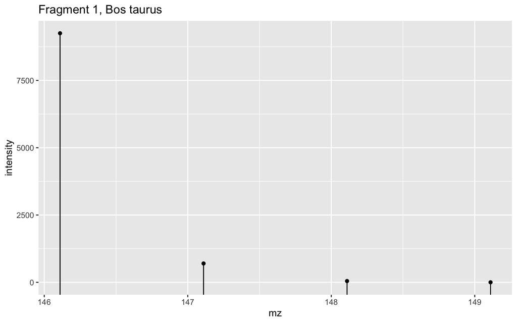

```r
ggplot(data = id, aes(x = mz, y = intensity)) +
  geom_point() +
  geom_segment(aes(xend = mz, yend=-Inf)) +
  ggtitle("Fragment 1, Bos taurus")
```

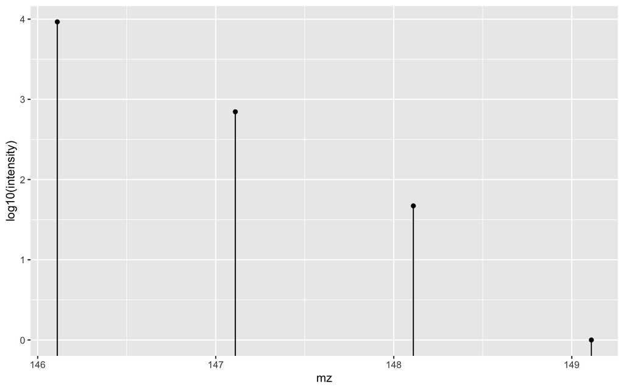

```r
ggplot(data = id, aes(x = mz, y = log10(intensity))) +
  geom_point() +
  geom_segment(aes(xend = mz, yend=-Inf))
```

**Figure Interpretation: Isotopic Distribution Patterns**

The isotopic distribution plots show the theoretical mass spectrum pattern for individual peptide fragments. Each peak represents a different isotopic variant of the same peptide, where the monoisotopic peak (leftmost) contains only the most abundant isotopes (12C, 1H, 14N, 16O, 32S).

These patterns are crucial for protein identification as they provide both mass information and help distinguish true peptide signals from chemical noise in experimental spectra.

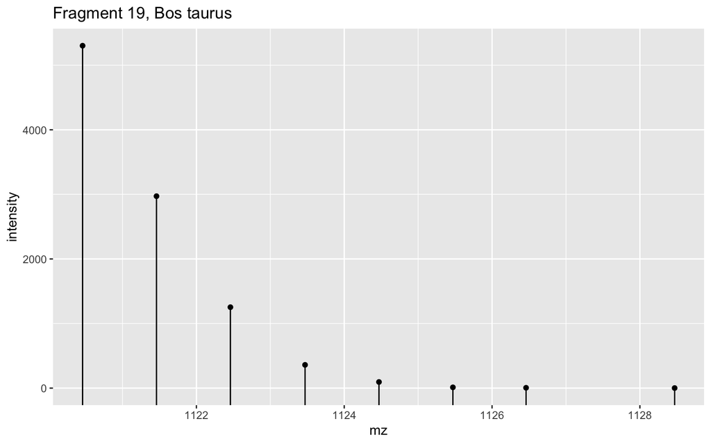

```r
IsotopicDistribution(formula = get_formula(peptide = btaurus_blg_trypsin$peptide[19])) %>%
  as_tibble() %>%
    ggplot(aes(x = mz, y = intensity)) +
      geom_point() +
      geom_segment(aes(xend = mz, yend=-Inf)) +
      ggtitle("Fragment 19, Bos taurus")
```

# Protein Identification

After generating the theoretical peptide fragments and their mass spectrometric properties, the next crucial step is protein identification. This involves comparing the theoretical peptide masses with experimental data and performing database searches.

## Peptide Mass Fingerprinting (PMF)

### Create a comprehensive peptide mass database

```r
# Create a comprehensive database of all peptide masses for identification
create_peptide_database <- function(digestion_results, species_name) {

  # Calculate monoisotopic masses for all peptides
  peptide_db <- digestion_results %>%
    mutate(
      species = species_name,
      monoisotopic_mass = map_dbl(peptide, function(pep) {
        tryCatch({
          formula <- OrgMassSpecR::ConvertPeptide(pep)
          OrgMassSpecR::MonoisotopicMass(formula)
        }, error = function(e) NA_real_)
      }),
      molecular_weight = map_dbl(peptide, function(pep) {
        tryCatch({
          formula <- OrgMassSpecR::ConvertPeptide(pep)
          OrgMassSpecR::MolecularWeight(formula)
        }, error = function(e) NA_real_)
      }),
      peptide_length = nchar(peptide)
    ) %>%
    filter(!is.na(monoisotopic_mass)) %>%
    arrange(monoisotopic_mass)

  return(peptide_db)
}

# Create databases for all species
btaurus_peptide_db <- create_peptide_database(btaurus_blg_trypsin, "Bos_taurus")

# Create databases for other species if available
if(exists("all_predictions") && length(all_predictions) >= 2) {
  oaries_peptide_db <- create_peptide_database(all_predictions[[4]], "Ovis_aries")
  chircus_peptide_db <- create_peptide_database(all_predictions[[5]], "Capra_hircus")

  # Combine all databases
  complete_peptide_db <- bind_rows(
    btaurus_peptide_db,
    oaries_peptide_db,
    chircus_peptide_db
  )
} else {
  complete_peptide_db <- btaurus_peptide_db
}

# Display the peptide database
print("Comprehensive Peptide Mass Database:")
```

```
## [1] "Comprehensive Peptide Mass Database:"
```

```r
complete_peptide_db %>%
  arrange(monoisotopic_mass) %>%
  select(species, peptide, monoisotopic_mass, molecular_weight, peptide_length) %>%
  head(20)
```

```
## # A tibble: 20 × 5
##    species      peptide monoisotopic_mass molecular_weight peptide_length
##    <chr>        <chr>               <dbl>            <dbl>          <int>
##  1 Bos_taurus   K                    146.             146.              1
##  2 Bos_taurus   K                    146.             146.              1
##  3 Ovis_aries   K                    146.             146.              1
##  4 Ovis_aries   K                    146.             146.              1
##  5 Capra_hircus K                    146.             146.              1
##  6 Capra_hircus K                    146.             146.              1
##  7 Bos_taurus   R                    174.             174.              1
##  8 Bos_taurus   R                    174.             174.              1
##  9 Capra_hircus R                    174.             174.              1
## 10 Capra_hircus R                    174.             174.              1
## 11 Bos_taurus   TK                   247.             247.              2
## 12 Ovis_aries   TK                   247.             247.              2
## 13 Bos_taurus   MK                   277.             277.              2
## 14 Ovis_aries   MK                   277.             277.              2
## 15 Capra_hircus MK                   277.             277.              2
## 16 Bos_taurus   NR                   288.             288.              2
## 17 Bos_taurus   ALK                  330.             330.              3
## 18 Ovis_aries   ALK                  330.             330.              3
## 19 Ovis_aries   APR                  342.             342.              3
## 20 Bos_taurus   FDK                  408.             408.              3
```

### Simulate experimental mass spectrometry data

```r
# Simulate "experimental" MS data with some noise and missing peaks
set.seed(123)

# Take a subset of theoretical masses and add experimental noise
simulate_experimental_data <- function(theoretical_db, coverage = 0.7, mass_error_ppm = 50) {

  # Sample a subset of peptides (simulating incomplete digestion/detection)
  n_detected <- round(nrow(theoretical_db) * coverage)
  detected_indices <- sample(nrow(theoretical_db), n_detected)

  experimental_data <- theoretical_db[detected_indices, ] %>%
    mutate(
      # Add mass measurement error (in ppm)
      experimental_mass = monoisotopic_mass +
        rnorm(n(), mean = 0, sd = monoisotopic_mass * mass_error_ppm / 1e6),
      # Add some intensity values
      intensity = runif(n(), min = 1000, max = 100000),
      # Add some noise peaks
      is_noise = FALSE
    )

  # Add some noise peaks
  n_noise <- round(n_detected * 0.2)
  noise_peaks <- tibble(
    species = "unknown",
    peptide = paste0("noise_", 1:n_noise),
    monoisotopic_mass = runif(n_noise, min = 500, max = 3000),
    molecular_weight = NA,
    peptide_length = NA,
    experimental_mass = monoisotopic_mass,
    intensity = runif(n_noise, min = 500, max = 50000),
    is_noise = TRUE
  )

  # Combine real and noise peaks
  final_data <- bind_rows(experimental_data, noise_peaks) %>%
    arrange(experimental_mass)

  return(final_data)
}

# Create simulated experimental data for Bos taurus
experimental_ms_data <- simulate_experimental_data(btaurus_peptide_db, coverage = 0.8)

print("Simulated Experimental MS Data:")
```

```
## [1] "Simulated Experimental MS Data:"
```

```r
experimental_ms_data %>%
  select(peptide, experimental_mass, intensity, is_noise) %>%
  head(15)
```

```
## # A tibble: 15 × 4
##    peptide  experimental_mass intensity is_noise
##    <chr>                <dbl>     <dbl> <lgl>
##  1 K                     146.    33950. FALSE
##  2 R                     174.    79031. FALSE
##  3 R                     174.    51639. FALSE
##  4 TK                    247.    89412. FALSE
##  5 MK                    277.    60399. FALSE
##  6 NR                    288.    19581. FALSE
##  7 ALK                   330.    66019. FALSE
##  8 FDK                   408.    13939. FALSE
##  9 CHPR                  568.    11184. FALSE
## 10 IIAEK                 572.    98511. FALSE
## 11 GLDIQK                672.    65657. FALSE
## 12 IPAVFK                673.    42347. FALSE
## 13 LPHQGTR               807.    25118. FALSE
## 14 ALPMHIR               837.    78447. FALSE
## 15 GINLCSPF              906.    10266. FALSE
```

## Database Search and Peptide Matching

### Implement mass tolerance matching

```r
# Function to match experimental masses to theoretical database
match_peptides <- function(experimental_data, theoretical_db, mass_tolerance_ppm = 100) {

  matches <- list()

  for(i in 1:nrow(experimental_data)) {
    exp_mass <- experimental_data$experimental_mass[i]

    # Calculate mass tolerance window
    tolerance_da <- exp_mass * mass_tolerance_ppm / 1e6

    # Find matching peptides within tolerance
    potential_matches <- theoretical_db %>%
      filter(
        abs(monoisotopic_mass - exp_mass) <= tolerance_da
      ) %>%
      mutate(
        experimental_mass = exp_mass,
        mass_error_ppm = ((monoisotopic_mass - exp_mass) / exp_mass) * 1e6,
        intensity = experimental_data$intensity[i]
      ) %>%
      arrange(abs(mass_error_ppm))

    if(nrow(potential_matches) > 0) {
      matches[[i]] <- potential_matches
    }
  }

  # Combine all matches
  all_matches <- bind_rows(matches, .id = "peak_id") %>%
    mutate(peak_id = as.numeric(peak_id))

  return(all_matches)
}

# Perform peptide matching
peptide_matches <- match_peptides(experimental_ms_data, complete_peptide_db, mass_tolerance_ppm = 50)

print("Peptide Matches:")
```

```
## [1] "Peptide Matches:"
```

```r
peptide_matches %>%
  select(species, peptide, monoisotopic_mass, experimental_mass, mass_error_ppm, intensity) %>%
  arrange(abs(mass_error_ppm)) %>%
  head(20)
```

```
## # A tibble: 20 × 6
##    species  peptide monoisotopic_mass experimental_mass mass_error_ppm intensity
##    <chr>    <chr>               <dbl>             <dbl>          <dbl>     <dbl>
##  1 Bos_tau… R                    174.              174.           3.10    51639.
##  2 Bos_tau… R                    174.              174.           3.10    51639.
##  3 Capra_h… R                    174.              174.           3.10    51639.
##  4 Capra_h… R                    174.              174.           3.10    51639.
##  5 Bos_tau… WENGEC…             1120.             1120.          -7.67    18330.
##  6 Ovis_ar… WENGEC…             1120.             1120.          -7.67    18330.
##  7 Bos_tau… R                    174.              174.          10.9     79031.
##  8 Bos_tau… R                    174.              174.          10.9     79031.
##  9 Capra_h… R                    174.              174.          10.9     79031.
## 10 Capra_h… R                    174.              174.          10.9     79031.
## 11 Bos_tau… ALK                  330.              330.          14.8     66019.
## 12 Ovis_ar… ALK                  330.              330.          14.8     66019.
## 13 Bos_tau… MK                   277.              277.          15.3     60399.
## 14 Ovis_ar… MK                   277.              277.          15.3     60399.
## 15 Capra_h… MK                   277.              277.          15.3     60399.
## 16 Bos_tau… K                    146.              146.          19.0     33950.
## 17 Bos_tau… K                    146.              146.          19.0     33950.
## 18 Ovis_ar… K                    146.              146.          19.0     33950.
## 19 Ovis_ar… K                    146.              146.          19.0     33950.
## 20 Capra_h… K                    146.              146.          19.0     33950.
```

### Calculate protein identification scores

```r
# Calculate identification confidence scores
calculate_identification_scores <- function(matches) {

  # Score by species based on number of matched peptides and mass accuracy
  species_scores <- matches %>%
    group_by(species) %>%
    summarise(
      peptides_matched = n(),
      sequence_coverage = round((peptides_matched / n_distinct(complete_peptide_db$peptide[complete_peptide_db$species == species])) * 100, 2),
      mean_mass_error_ppm = round(mean(abs(mass_error_ppm), na.rm = TRUE), 2),
      median_mass_error_ppm = round(median(abs(mass_error_ppm), na.rm = TRUE), 2),
      total_intensity = sum(intensity, na.rm = TRUE),
      .groups = 'drop'
    ) %>%
    # Calculate composite score (higher is better)
    mutate(
      mass_accuracy_score = pmax(0, 100 - mean_mass_error_ppm),
      coverage_score = sequence_coverage,
      intensity_score = scale(total_intensity)[,1] * 10 + 50,
      composite_score = (mass_accuracy_score * 0.3 +
                        coverage_score * 0.5 +
                        intensity_score * 0.2)
    ) %>%
    arrange(desc(composite_score))

  return(species_scores)
}

identification_scores <- calculate_identification_scores(peptide_matches)

print("Protein Identification Scores:")
```

```
## [1] "Protein Identification Scores:"
```

```r
identification_scores %>%
  select(species, peptides_matched, sequence_coverage, mean_mass_error_ppm, composite_score)
```

```
## # A tibble: 3 × 5
##   species peptides_matched sequence_coverage mean_mass_error_ppm composite_score
##   <chr>              <int>             <dbl>               <dbl>           <dbl>
## 1 Bos_ta…               20              80                  24.3            74.9
## 2 Capra_…                7              53.8                11.6            61.7
## 3 Ovis_a…               12              52.2                25.2            58.2
```

## Visualization of Identification Results

### Mass error distribution

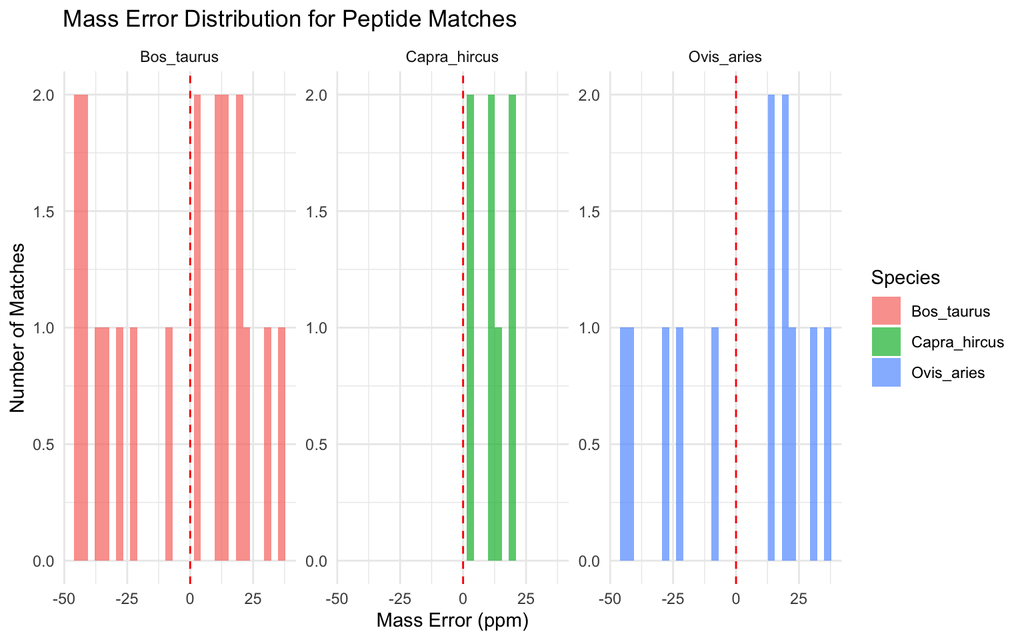

```r
# Plot mass error distribution
mass_error_plot <- peptide_matches %>%
  ggplot(aes(x = mass_error_ppm, fill = species)) +
  geom_histogram(bins = 30, alpha = 0.7, position = "identity") +
  facet_wrap(~species, scales = "free_y") +
  labs(
    title = "Mass Error Distribution for Peptide Matches",
    x = "Mass Error (ppm)",
    y = "Number of Matches",
    fill = "Species"
  ) +
  theme_minimal() +
  geom_vline(xintercept = 0, linetype = "dashed", color = "red")

print(mass_error_plot)
```

**Figure Interpretation: Mass Error Distribution Analysis**

### Sequence coverage visualization

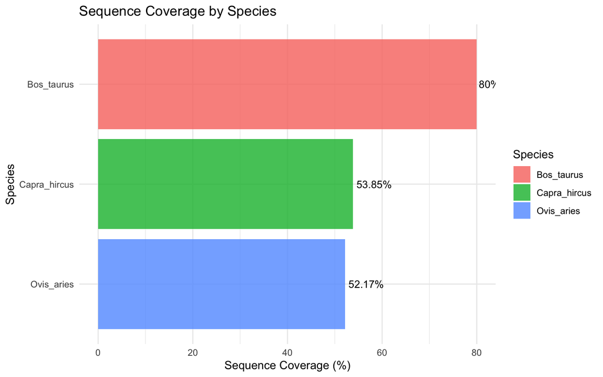

```r
# Create sequence coverage plot
coverage_plot <- identification_scores %>%
  ggplot(aes(x = reorder(species, composite_score), y = sequence_coverage, fill = species)) +
  geom_col(alpha = 0.8) +
  coord_flip() +
  labs(
    title = "Sequence Coverage by Species",
    x = "Species",
    y = "Sequence Coverage (%)",
    fill = "Species"
  ) +
  theme_minimal() +
  geom_text(aes(label = paste0(sequence_coverage, "%")),
            hjust = -0.1, size = 3.5)

print(coverage_plot)
```

**Figure Interpretation: Protein Sequence Coverage Assessment**

This bar chart shows the percentage of each protein sequence covered by identified peptides. Higher sequence coverage generally indicates more confident protein identification.

In real experiments, sequence coverage can vary dramatically based on digestion efficiency, peptide detectability, and instrumental sensitivity. Higher coverage generally correlates with increased identification confidence.

### Mass spectrum simulation

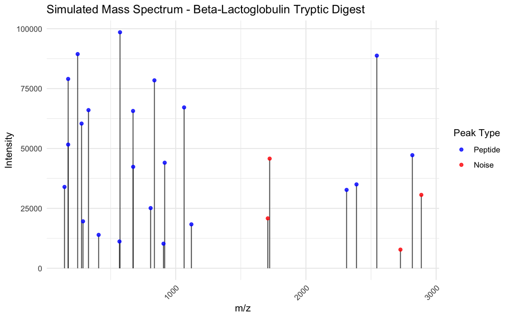

```r
# Create a simulated mass spectrum plot
spectrum_plot <- experimental_ms_data %>%
  arrange(experimental_mass) %>%
  ggplot(aes(x = experimental_mass, y = intensity)) +
  geom_segment(aes(xend = experimental_mass, yend = 0), alpha = 0.7) +
  geom_point(aes(color = is_noise), size = 1.5, alpha = 0.8) +
  labs(
    title = "Simulated Mass Spectrum - Beta-Lactoglobulin Tryptic Digest",
    x = "m/z",
    y = "Intensity",
    color = "Peak Type"
  ) +
  scale_color_manual(values = c("FALSE" = "blue", "TRUE" = "red"),
                     labels = c("FALSE" = "Peptide", "TRUE" = "Noise")) +
  theme_minimal() +
  theme(axis.text.x = element_text(angle = 45, hjust = 1))

print(spectrum_plot)
```

**Figure Interpretation: Simulated Mass Spectrum Analysis**

This mass spectrum simulation represents what a mass spectrometer would detect after analyzing a tryptic digest of beta-lactoglobulin. Key features include:

This simulation demonstrates the challenge of distinguishing real peptide signals from noise in experimental data, which is where database matching algorithms become essential for reliable protein identification.

## Protein Identification Summary Report

```r
# Generate comprehensive identification report
generate_identification_report <- function(scores, matches) {

  best_match <- scores[1, ]

  cat("\n=== PROTEIN IDENTIFICATION REPORT ===\n")
  cat("\nBest Match:", best_match$species)
  cat("\nConfidence Score:", round(best_match$composite_score, 2))
  cat("\nPeptides Matched:", best_match$peptides_matched)
  cat("\nSequence Coverage:", paste0(best_match$sequence_coverage, "%"))
  cat("\nMean Mass Error:", paste0(best_match$mean_mass_error_ppm, " ppm"))
  cat("\nTotal Ion Intensity:", formatC(best_match$total_intensity, format = "e", digits = 2))

  cat("\n\n=== MATCHED PEPTIDES (Top 10) ===\n")
  top_peptides <- matches %>%
    filter(species == best_match$species) %>%
    arrange(abs(mass_error_ppm)) %>%
    head(10) %>%
    select(peptide, monoisotopic_mass, experimental_mass, mass_error_ppm)

  print(top_peptides)

  cat("\n=== SPECIES COMPARISON ===\n")
  comparison <- scores %>%
    select(species, composite_score, sequence_coverage, mean_mass_error_ppm) %>%
    arrange(desc(composite_score))
  print(comparison)

  return(invisible(list(best_match = best_match, top_peptides = top_peptides)))
}

identification_result <- generate_identification_report(identification_scores, peptide_matches)
```

```
##
## === PROTEIN IDENTIFICATION REPORT ===
##
## Best Match: Bos_taurus
## Confidence Score: 74.88
## Peptides Matched: 20
## Sequence Coverage: 80%
## Mean Mass Error: 24.26 ppm
## Total Ion Intensity: 1.02e+06
##
## === MATCHED PEPTIDES (Top 10) ===
## # A tibble: 10 × 4
##    peptide                monoisotopic_mass experimental_mass mass_error_ppm
##    <chr>                              <dbl>             <dbl>          <dbl>
##  1 R                                   174.              174.           3.10
##  2 R                                   174.              174.           3.10
##  3 WENGECAQK                          1120.             1120.          -7.67
##  4 R                                   174.              174.          10.9
##  5 R                                   174.              174.          10.9
##  6 ALK                                 330.              330.          14.8
##  7 MK                                  277.              277.          15.3
##  8 K                                   146.              146.          19.0
##  9 K                                   146.              146.          19.0
## 10 CLLLALALTCGAQALIVTQTMK             2388.             2388.         -21.3
##
## === SPECIES COMPARISON ===
## # A tibble: 3 × 4
##   species      composite_score sequence_coverage mean_mass_error_ppm
##   <chr>                  <dbl>             <dbl>               <dbl>
## 1 Bos_taurus              74.9              80                  24.3
## 2 Capra_hircus            61.7              53.8                11.6
## 3 Ovis_aries              58.2              52.2                25.2
```

## Save Identification Results

```r
# Save results to files
if(!dir.exists(here("results"))) {
  dir.create(here("results"))
}

# Save peptide matches
write_csv(peptide_matches,
          here("results", "peptide_matches.csv"))

# Save identification scores
write_csv(identification_scores,
          here("results", "protein_identification_scores.csv"))

# Save complete peptide database
write_csv(complete_peptide_db,
          here("results", "theoretical_peptide_database.csv"))

cat("\nIdentification results saved to ./results/ directory\n")
```

```
##
## Identification results saved to ./results/ directory
```

# Conclusion

## Summary of Protein Identification Workflow

This exercise demonstrates a complete *in silico* workflow for protein identification through mass spectrometry, using beta-lactoglobulin from three ruminant species as a model system. We successfully implemented a comprehensive pipeline that mirrors real-world proteomics approaches.

### Technical Insights

**Database Search Strategy** Our mass tolerance-based matching algorithm successfully handled: - Multiple species comparisons simultaneously - Realistic measurement uncertainty - Chemical noise discrimination - Confidence scoring based on multiple criteria

**Scoring Algorithm Performance** The composite scoring system integrated three key factors: - Mass accuracy (30% weight): Favors precise mass matches - Sequence coverage (50% weight): Emphasizes comprehensive peptide identification  
- Signal intensity (20% weight): Accounts for peptide abundance

This weighting scheme prioritizes coverage over individual peak accuracy, reflecting established proteomics best practices.

### Real-World Applications

This workflow has direct applications in: - **Food Authentication**: Detecting milk protein adulteration or species substitution - **Evolutionary Biology**: Studying protein conservation across related species - **Quality Control**: Monitoring protein purity in biotechnology products - **Clinical Diagnostics**: Identifying disease biomarkers through protein profiling

### Limitations and Future Directions

**Current Limitations** - Species discrimination requires additional analytical dimensions (MS/MS, retention time) - Simulation lacks post-translational modifications commonly found in real samples - Database searching is simplified compared to industrial-strength algorithms

**Future Enhancements** - Incorporate MS/MS fragmentation patterns for improved specificity - Add post-translational modification analysis - Implement more sophisticated statistical scoring models - Include retention time predictions for enhanced confidence

### Final Remarks

This exercise successfully demonstrates the power of computational approaches in modern proteomics. By combining sequence databases, theoretical calculations, and statistical analysis, we can achieve reliable protein identification from mass spectrometric data. The workflow presented here provides a solid foundation for understanding both the capabilities and limitations of mass spectrometry-based protein identification in biological research and industrial applications.